# **Création automatisée de dossier personnel**

## **Dossier de partage**

Créez un dossier utilisateurs

Partagez ce dossier et ajouter le symbole dollar « $ » après le nom de partage pour cacher le nom de partage.

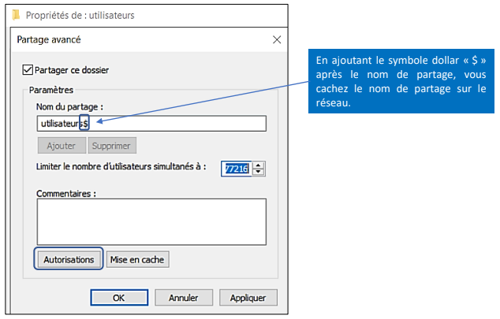

image

Cliquez sur « Autorisations »

Supprimez le groupe « Tout le monde » des autorisations et cliquez le bouton « Ajouter » :

[figure not shown]

image

Cliquez sur Avancée

Cliquez le bouton « Rechercher » et sélectionnez « Administrateur » et « Utilisateurs authentifiés »

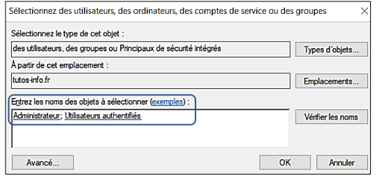

image

Accordez un contrôle total sur ce partage pour les utilisateurs sélectionnés et validez vos choix.

Le dossier est maintenant partagé.

Cliquez l’onglet « Sécurité » et accédez aux réglages avancés en cliquant le bouton « Avancé »

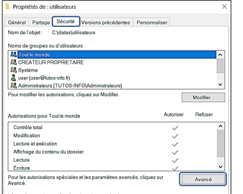

image

Cliquez sur « Désactiver l’héritage »

[figure not shown]

image

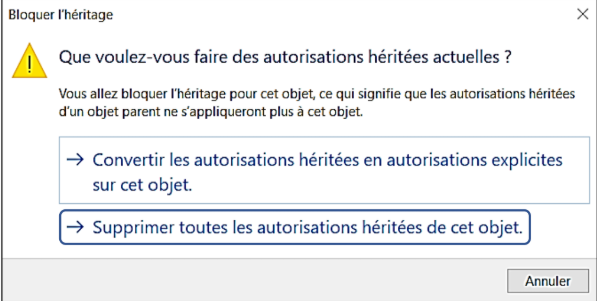

image

Une fois que la liste est vide, Ajouter les autorisations.

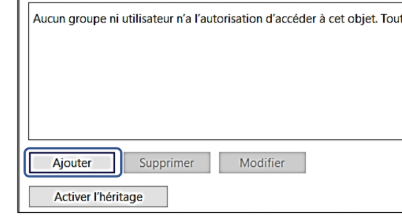

image

Cliquez sur le lien « Sélectionner un principal »

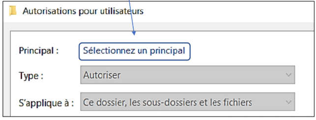

image

Dans la fenetre suivante, entrer (à l’aide de *Vérifier les noms*),

`- CREATEUR PROPRIETAIRE`  
`- Système`  
`- utilisateurs authentifiés`  
`- Administrateurs`  
A chaque fois en donnant un contrôle total.

## **Création de la GPO**

Sur le domaine, créer une GPO, nommé par exemple *Création automatique dossier personnel utilisateur*.

### **Paramètre *Dossier***

Dans la GPO, aller à configuration utilisateur -> Préférences -> Dossiers et Nouveau Dossier.

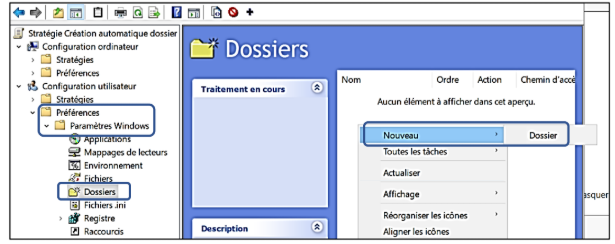

image

Compléter avec le chemin d’accès.

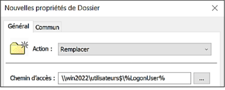

image

Dans l’onglet Commun, cocher *Exécuter dans le contexte…*

La fenêtre affiche vos paramètres

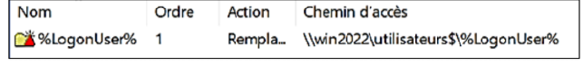

image

### **Paramètre *Mappage***

Sélectionner Mappage de lecteurs puis Nouveau, Lecteur mappé

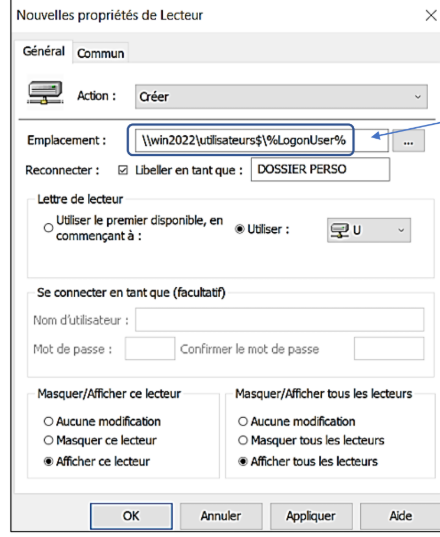

image

Compléter, Action, Emplacement, Reconnecter, Libeller, Utiliser et sélectionner Afficher.

Dans l’onglet commun, cocher *Exécuter dans le contexte…*

### **Raccourcis**

Sélectionner maintenant Rccourcis et Nouveau, Racourci.

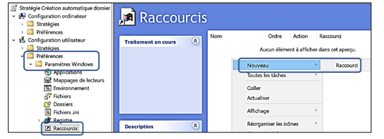

image

Compléter la fenêtre :

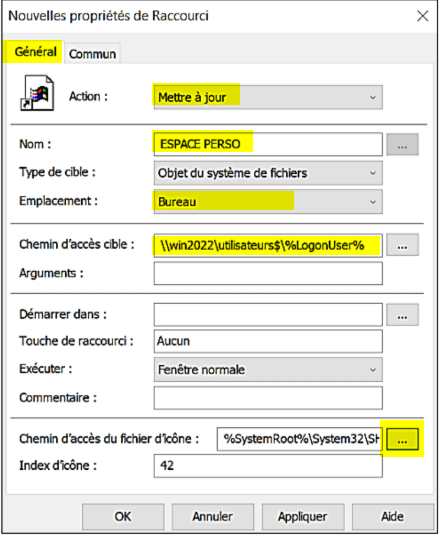

image

Dans l’onglet commun, cocher *Exécuter dans le contexte…*

La fenêtre affiche les paramètres du raccourci tel qu’il a été configuré.

[figure not shown]

image

## **Test du fonctionnement sur un ordinateur utilisateur**

Se connecter ou dans cmd gpupdate /force